# pagerank

2018/4/21

1.notice that the value of $p_{ij}$ depends on the value of $r_i$, i.e.,

$$\begin{equation}
\left\{
\begin{aligned}
p_{ij} &= \frac{1}{n}, &if \ r_i = 0 \\
p_{ij} &= \frac{a_{ij}p}{r_i} + \frac{1-p}{n}, &if \ r_i > 0\\
\end{aligned}
\right.
\end{equation}$$

so if we write this to the matrix form, we need to use an indicator variable $I(r_i > 0)$, which denotes

$$\begin{equation}
I(r_i > 0) =
\left\{
\begin{aligned}
&0, &if \ r_i = 0\\
&1, &if \ r_i > 0\\
\end{aligned}
\right.
\end{equation}$$

in this case we can write the transition matrix $P$ as

$$\begin{equation}
P = RA + q1_n^T
\end{equation}$$

where $R$ is a diagonal matrix, with it’s $(i,j)$-element is

$$\begin{equation}
R_{ij} =
\left\{
\begin{aligned}
& \frac{p}{r_i}I(r_i > 0), &if \ i = j \\
&0, &if \ i \not= j \\
\end{aligned}
\right.
\end{equation}$$

and $q$ is a vector, with it’s $i$-element is

$$\begin{equation}
q_i = \frac{(1-pI(r_i > 0))}{n}
\end{equation}$$

2.based on the derivation of 1, we can calculate the objects by the following codes.

```r
# load package
library(Matrix)
# set directory
setwd('/Users/lemuria/Bill/PageRank/')
# load data
web <- read.table('websites.txt',sep = '\t')
head(web)
```

```
##                                                V1
## 1                      http://canr.udel.edu/apec/
## 2 http://www.udel.edu/modules/icons/images/ud.ico
## 3                 http://canr.udel.edu/xmlrpc.php
## 4        http://w.sharethis.com/button/buttons.js
## 5                       http://canr.udel.edu/feed
## 6              http://canr.udel.edu/comments/feed
```

```r
A <- as.matrix(read.table("adjacency.txt",sep = ','))
A[1:10,1:10]
```

```
##       V1 V2 V3 V4 V5 V6 V7 V8 V9 V10
##  [1,]  0  1  1  1  1  1  1  1  1   1
##  [2,]  0  0  0  0  0  0  0  0  0   0
##  [3,]  0  0  0  0  0  0  0  0  0   0
##  [4,]  0  0  0  0  0  0  0  0  0   0
##  [5,]  0  0  0  0  1  0  0  0  0   0
##  [6,]  0  0  0  0  0  1  0  0  0   0
##  [7,]  0  0  0  0  0  0  1  0  0   0
##  [8,]  0  0  0  0  0  0  0  0  0   0
##  [9,]  0  0  0  0  0  0  0  1  0   0
## [10,]  0  0  0  0  0  0  0  0  0   0
```

```r
p <- 0.9
n <- nrow(A)
# (a)
r <- rowSums(A)
# (b)
R_diag <- ifelse(r > 0, p/r, 0)
print(head(R_diag,10))
```

```
##  [1] 0.01304348 0.00000000 0.00000000 0.15000000 0.03333333 0.22500000
##  [7] 0.22500000 0.00000000 0.03461538 0.90000000
```

```r
# (c)
q <- (1 - p * as.numeric(r > 0))/n
print(head(q,10))
```

```
##  [1] 2e-04 2e-03 2e-03 2e-04 2e-04 2e-04 2e-04 2e-03 2e-04 2e-04
```

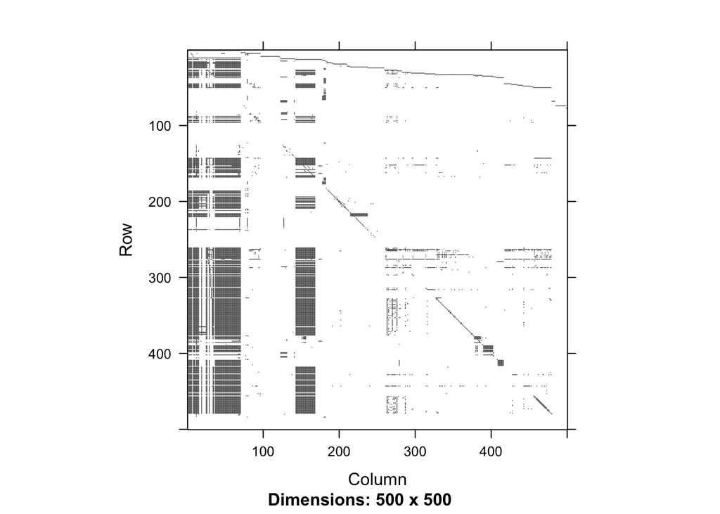

```r
# (d)
A_sp <- Matrix(A,sparse = TRUE)
image(A_sp)
```

3.we can generate a inital eigenvector value x randomly and keep updating $P_{T}x$ until convergence, we use the value of max distance beween the $P_{T}$ and $P_{T+1}$ as the convergence judgment basis.

```r
# use power method to calculate eigenvector x
P <- diag(R_diag) %*% A_sp + q %*% t(rep(1,n))

# generated initial value randomly
x <- runif(n,0,1)
x <- x/sum(x)

y <- t(P) %*% x
thresold <- 1e-5

while (TRUE) {
  y1 <- t(P) %*% y
  e <- max(abs(y1-y))
  # print(e)
  if(e < thresold){
    break
  }        # if e is smaller enough, stop the loop
  y <- y1
}
x1 <- as.vector(y1[,1])
print(head(x1,20))  # print the first 20 elements of eigenvector
```

```
##  [1] 0.0007226129 0.0052823756 0.0045130742 0.0052823756 0.0046687007
##  [6] 0.0058233570 0.0010075119 0.0046692992 0.0045130742 0.0045130742
## [11] 0.0037396599 0.0305560897 0.0082302356 0.0045130742 0.0063452401
## [16] 0.0011603476 0.0011603476 0.0012287768 0.0035900720 0.0011603476
```

4. use the eigen function to calculate the eigenvector with the eigenvalue equals 1.

```r
# use eigen function to calculate the top eigenvector directly
x <- Re(eigen(t(P))$vectors[,1])
x <- x/sum(x)
x2 <- x
print(head(x2,20))
```

```
##  [1] 0.0007225041 0.0052814305 0.0045122731 0.0052814305 0.0046678687
##  [6] 0.0058222878 0.0010073519 0.0046684671 0.0045122731 0.0045122731
## [11] 0.0037390055 0.0305494860 0.0082286230 0.0045122731 0.0063440405
## [16] 0.0011601610 0.0011601610 0.0012285777 0.0035894445 0.0011601610
```

5.if can be seen that

$$\begin{equation}
x = p_{T}x = (RA + a1_n^T)^Tx
\end{equation}$$

which can be shown to be equivalent to

$$\begin{equation}
(A^TR^T - I_n)x = -(q^Tx)1_n.
\end{equation}$$

since we need to scale x for comparison, in this case, we have

$$\begin{equation*}
\sum_{i=1}^Nx_i = 1
\end{equation*}$$

so we can infer that

$$\begin{equation}
(A^TR^T - I_n)x = -1_nq^Tx = -1_nq^T(1_n1_n^T)x = -1_nq^T1_n(1_n^Tx) = -1_nq^T1_n
\end{equation}$$

so if we solve the equation above, we can ignore the scalar above.

```r
a <- t(A) %*% t(diag(R_diag)) - diag(1,n)
b <- -rep(1,n) %*% t(q) %*% rep(1,n)
x <- base::solve(a,b)
x <- x/sum(x)
x3 <- x[,1]
print(head(x3,20))
```

```
##  [1] 0.0007225041 0.0052814305 0.0045122731 0.0052814305 0.0046678687
##  [6] 0.0058222878 0.0010073519 0.0046684671 0.0045122731 0.0045122731
## [11] 0.0037390055 0.0305494860 0.0082286230 0.0045122731 0.0063440405
## [16] 0.0011601610 0.0011601610 0.0012285777 0.0035894445 0.0011601610
```

6.the first method is an approximation method of the true value, while we can calculate the theoretical value by the second and third method.

```r
top25 <- web[order(x2,decreasing = TRUE),][1:25]
print(top25)
```

```
##  [1] http://www.udel.edu
##  [2] http://ns.adobe.com/xap/1.0
##  [3] http://ns.adobe.com/xap/1.0/mm
##  [4] http://ns.adobe.com/xap/1.0/sType/ResourceRef
##  [5] http://purl.org/dc/elements/1.1
##  [6] http://www.udel.edu/home/legal-notices/accessibility
##  [7] http://www.aaea.org
##  [8] http://www.pcs.udel.edu
##  [9] http://library.udel.edu
## [10] http://www.udel.edu/home/legal-notices
## [11] http://grad.udel.edu
## [12] http://purl.org/rss/1.0/modules/content
## [13] http://www.bluehens.com
## [14] http://canr.udel.edu
## [15] http://www.udel.edu/home/comments
## [16] http://www.jswconline.org/content/72/5/493
## [17] http://www.udconnection.com
## [18] http://delawarefirst.udel.edu
## [19] http://www.srsa.org
## [20] http://www1.udel.edu/maps
## [21] http://www1.udel.edu/peoplesearch
## [22] http://online.udel.edu
## [23] http://www1.udel.edu/admissions/virtual-tour
## [24] http://www.udel.edu/udel-search
## [25] http://www.day.com/dam/1.0
## 485 Levels: http:/ ... http://www1.udel.edu/udaily/2014/oct/mexico-deforestation-100813.html
```